# EDA of Prosper Loan Data By Ramamohan Soma

Now lets see the correlation coefficients for the below pairs using sampling data. CreditScoreRangeUpper vs LoanOriginalAmount LoanOriginalAmount vs MonthlyLoanPayment

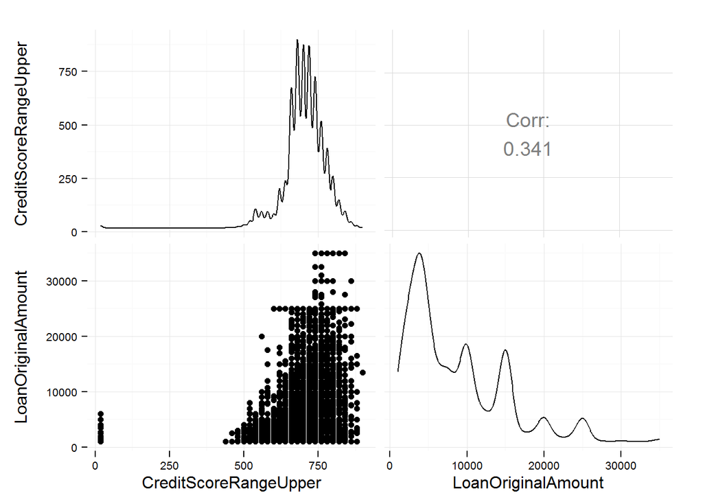

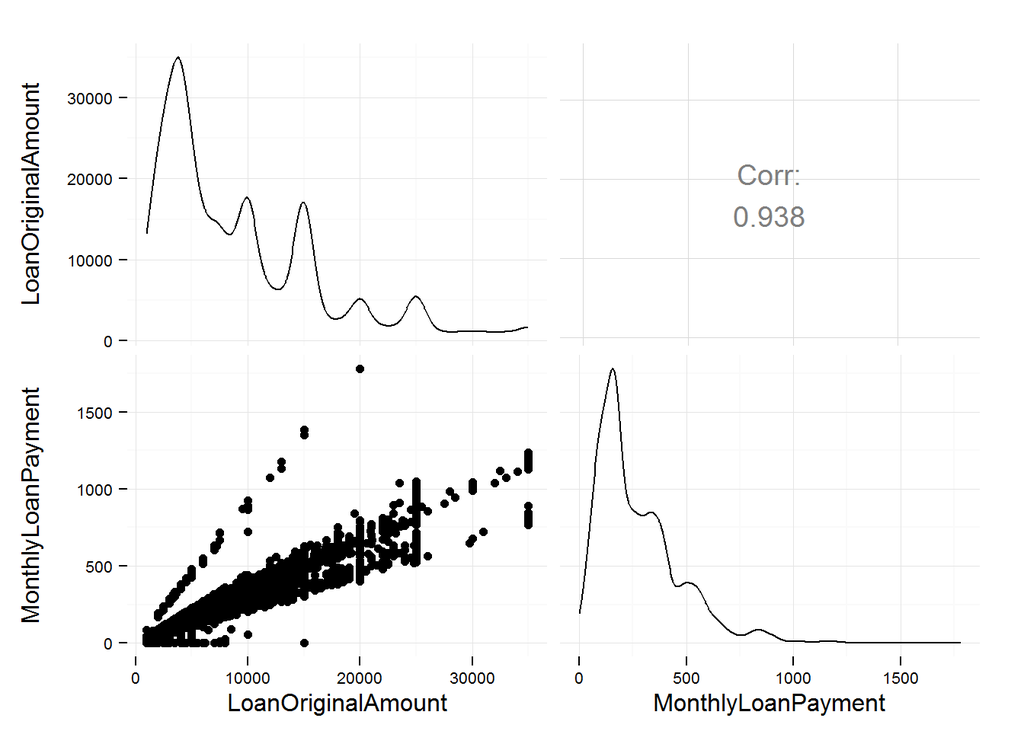

In the above plots, correlation co-efficient is high between LoanOriginalAmount and MonthlyLoanPayment.

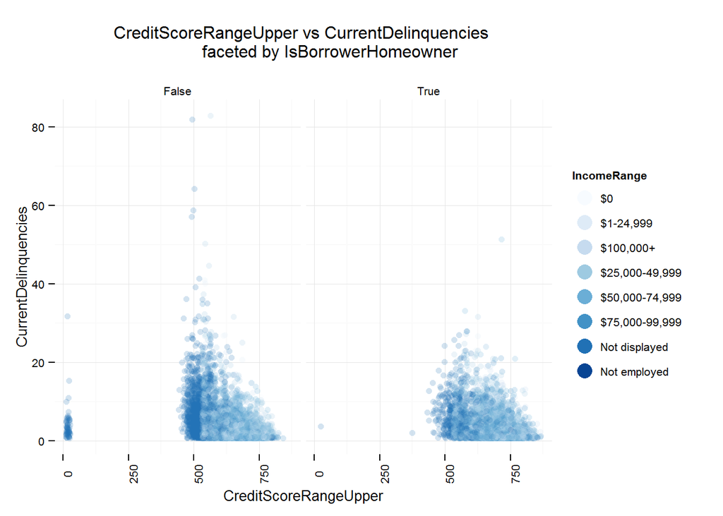

In the above plot most of the Borrowers with deliquencies if Homeowner or Non Homeowner, fall under credit score range of 400 to 700. Some Non Homeowner borrowers with high deliquencies have credit score of appx 500 and I think their Income Range is ‘Not displayed’. In case of Non Homeowners all the borrowers with Income Range of ‘Not displayed’ are clustered between credit scores of 450-550. Borrowers with Income Ranges of $25,000-49,000 and $50,000-74,000 and $75,000-99,000 are clustered between 600 to 800 credit scores.

I want to build a linear model to predict the Loan Amount. I am using the varibales LoanOriginalAmount, MonthlyLoanPayment, EmploymentStatus, CreditScoreRangeUpper and IncomeRange

```
##
## Calls:
## m1: lm(formula = I(log(LoanOriginalAmount)) ~ I(MonthlyLoanPayment^(1/3)),
##     data = LoanData)
## m2: lm(formula = I(log(LoanOriginalAmount)) ~ I(MonthlyLoanPayment^(1/3)) +
##     MonthlyLoanPayment, data = LoanData)
## m3: lm(formula = I(log(LoanOriginalAmount)) ~ I(MonthlyLoanPayment^(1/3)) +
##     MonthlyLoanPayment + EmploymentStatus, data = LoanData)
## m4: lm(formula = I(log(LoanOriginalAmount)) ~ I(MonthlyLoanPayment^(1/3)) +
##     MonthlyLoanPayment + EmploymentStatus + CreditScoreRangeUpper,
##     data = LoanData)
## m5: lm(formula = I(log(LoanOriginalAmount)) ~ I(MonthlyLoanPayment^(1/3)) +
##     MonthlyLoanPayment + EmploymentStatus + CreditScoreRangeUpper +
##     IncomeRange, data = LoanData)
##
## =======================================================================================
##                                      m1         m2         m3         m4         m5
## ---------------------------------------------------------------------------------------
## (Intercept)                       5.876***   6.090***   6.108***   5.437***   5.424***
##                                  (0.004)    (0.007)    (0.009)    (0.013)    (0.031)
## I(MonthlyLoanPayment^(1/3))       0.468***   0.411***   0.385***   0.378***   0.374***
##                                  (0.001)    (0.002)    (0.002)    (0.002)    (0.002)
## MonthlyLoanPayment                           0.000***   0.001***   0.001***   0.001***
##                                             (0.000)    (0.000)    (0.000)    (0.000)
## EmploymentStatus: Employed                              0.167***   0.088***   0.056*
##                                                        (0.007)    (0.008)    (0.027)
## EmploymentStatus: Full-time                             0.035***  -0.020**   -0.047
##                                                        (0.007)    (0.008)    (0.027)
## EmploymentStatus: Not available                        -0.015*     0.004      0.005
##                                                        (0.008)    (0.008)    (0.008)
## EmploymentStatus: Not employed                         -0.034**   -0.119***   0.032
##                                                        (0.013)    (0.013)    (0.060)
## EmploymentStatus: Other                                 0.095***   0.013      0.012
##                                                        (0.008)    (0.009)    (0.027)
## EmploymentStatus: Part-time                            -0.005     -0.057***  -0.011
##                                                        (0.011)    (0.012)    (0.028)
## EmploymentStatus: Retired                               0.007     -0.073***  -0.061*
##                                                        (0.013)    (0.013)    (0.029)
## EmploymentStatus: Self-employed                         0.081***  -0.001     -0.019
##                                                        (0.008)    (0.008)    (0.027)
```

[output cut: 13 more lines]

```
##                                                                              (0.028)
## IncomeRange: Not employed/$0                                                 -0.101
##                                                                              (0.057)
## ---------------------------------------------------------------------------------------
## R-squared                             0.841      0.843      0.850      0.857      0.858
## adj. R-squared                        0.841      0.843      0.850      0.857      0.858
## sigma                                 0.317      0.315      0.309      0.301      0.299
## F                                604132.490 306156.867  64320.060  61578.557  38172.677
## p                                     0.000      0.000      0.000      0.000      0.000
## Log-likelihood                   -30769.045 -30123.227 -27747.098 -24783.331 -24086.193
## Deviance                          11448.685  11319.631  10857.206  10276.626  10150.987
## AIC                               61544.089  60254.454  55518.197  49592.662  48212.385
## BIC                               61573.020  60293.027  55633.917  49717.958  48405.149
## N                                113937     113937     113937     113346     113346
## =======================================================================================
```

The variables in this model can account for 85% of variance in the Loan Amount issued to Borrower.

# Multivariate Analysis

### Talk about some of the relationships you observed in this part of the investigation. Were there features that strengthened each other in terms of looking at your feature(s) of interest?

After introducing “Year” and “CreditSCoreRangeUpper”, it strengthened my other features of interest and I could see more details from the plots. Surprisingly in the Year 2006 most of the deliqeuncies were from borrowers whose Income range was “Not displayed”. May it was because Prosper formed that year and guide lines might not be stricter. In 2009 number of deliquencies dropped significantly as the guide lines were made stricter. Employed and FullTime borrowers had more delinquencies as they have more loans compared to other borrowers. Non Homeowners have more deliquencies. Borrowers with high credit scores have loans with lower interest rates.

### Were there any interesting or surprising interactions between features?

I did a further investigation by taking the mean of “LoanOrignalAmount” and plotting against “CreditSCoreRangeUpper”. I found that for Non Homeowners Loan Amount increased by credit score but for Homeowners I see a drop in the LoanAmount for the credit scores more than 800.

### OPTIONAL: Did you create any models with your dataset? Discuss the strengths and limitations of your model.

# Final Plots and Summary

### Plot One

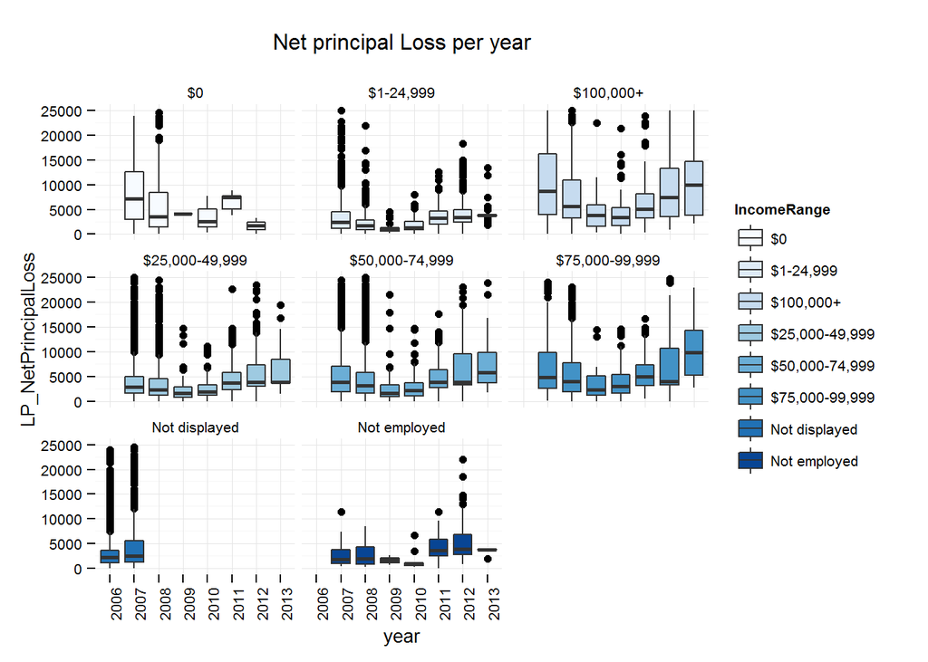

### Plot Two

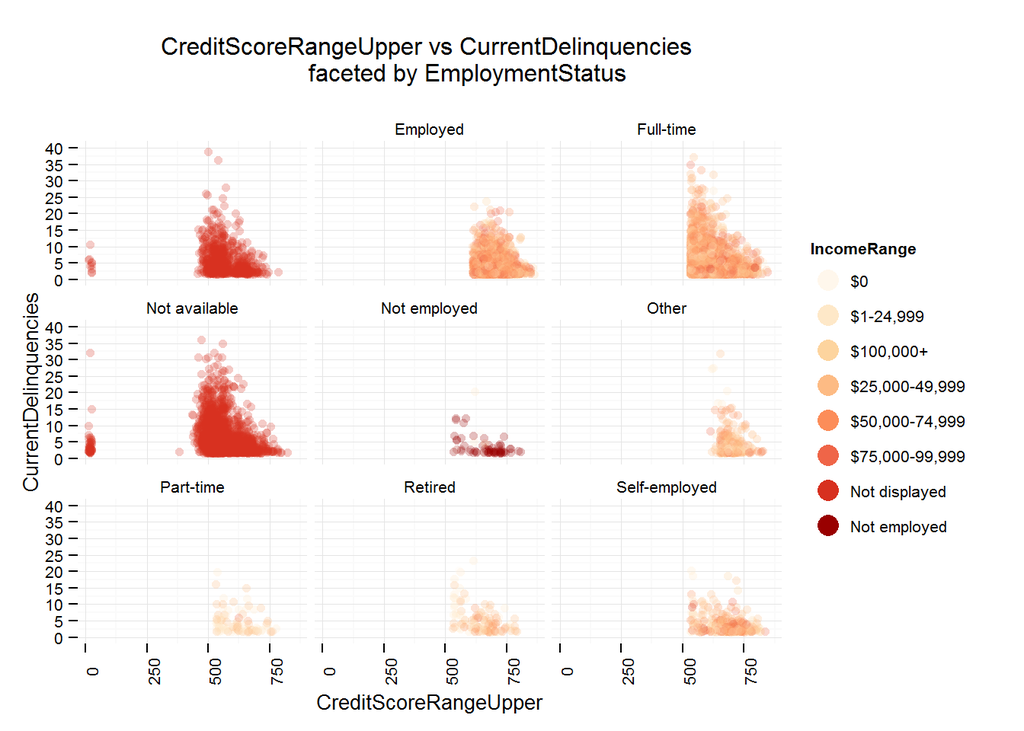

### Description Two

In Bi-variate section I saw that the median of delinquencies is high at credit score of 439, 459 and dereased by increase in credit score upto 659 and remains a 1 after that. In Multi-Variate section I saw some Non Homeowner borrowers with high deliquencies have credit score of appx 500 and I think their Income Range is ‘Not displayed’. In case of Non Homeowners all the borrowers with Income Range of ‘Not displayed’ are clustered between credit scores of 450-550. Now I want to see how the number of deliquencies varies with credit score based on borrowers employment status.

In the above plot I am considering Deliquencies which are greater than 1 (as there as my entries with 1 and causing overplotting at the bottom of the plot.) and reduced the y-axis scale to 40 so that plots are clear.

### Plot Three

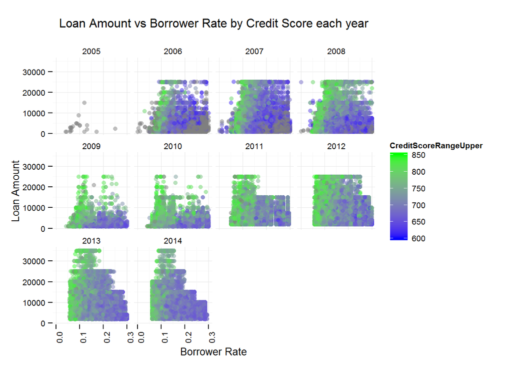

### Description Three

In the Uni-variate section I saw a spike in count for the borrower rate of 0.3177. On further analysis in Bi-variate section I have observed Many borrowers with ‘Employed’ status with various Income Ranges have this rate.In this section I want to see how BorrowerRate for Loan Amounts varies by CreditScoreRangeUpper for each year.

I can see from above plot, borrowers with high Upper Range Creditscore are in the left of the plot and they generally have low interest rates. From 2010 to 2014 we can see Low Upper Range credit score borrowers have high interest rates. I think this is because of making the guide lines strict in 2009. In 2006,2007,2008 I see borrowers with credit score in the range 600-700 have many loans. In 2009 the number of loans for them decreased and gradually increased again from 2011 to 2014.

# Reflection

From my analysis it seems like Propser struggled in the intial years until 2008 with many deliquencies, no strict rules etc. As we can see there was no proper information like Income Range, Employment Status about the borrowers. In 2009 once Prosper was restructured and made the rules stricter, I can see the deliquencies dropped significantly.

I would like to explore more on how Interest and fees are varying among different Loans, how the loans are distributed accross different states. Also I want to learn more about the models and create more models on this data using the other features in the data for example model loans likely to be deliquent based on credit scores.

# References

- Common function in R: http://discussions.udacity.com/t/common-function-in-r/10404/2
- Reshape: http://www.statmethods.net/management/reshape.html
- Date Formats in R: http://www.r-bloggers.com/date-formats-in-r/
- Do more with dates and times in R with lubridate: http://cran.r-project.org/web/packages/lubridate/vignettes/lubridate.html
- Introduction of dplyr: dplyr Tutorial Part 1 : http://www.r-bloggers.com/hadley-wickhams-dplyr-tutorial-at-user-2014-part-1/
- Types of smoothers in ggplot2: http://www.ats.ucla.edu/stat/r/faq/smooths.htm
- An Introduction to reshape2 by Sean Anderson: http://seananderson.ca/2013/10/19/reshape.html
- Converting Between Long and Wide Format: http://www.cookbook-r.com/Manipulating_data/Converting_data_between_wide_and_long_format/
- Melt Data Frames: http://www.r-bloggers.com/melt/
- Cut Function: http://www.r-bloggers.com/r-function-of-the-day-cut-2/
- Bayesian Statistics and Marketing: http://www.perossi.org/home/bsm-1
- QuickR’s Graphical Parameters: http://www.statmethods.net/advgraphs/parameters.html
- facet_wrap: http://docs.ggplot2.org/0.9.3.1/facet_wrap.html
- Log Transformations: http://www.r-statistics.com/2013/05/log-transformations-for-skewed-and-wide-distributions-from-practical-data-science-with-r/
- Basic Structure of a Function: https://www.youtube.com/watch?v=Z1wB1rHAYzQ&list=PLOU2XLYxmsIK9qQfztXeybpHvru-TrqAP
- Defining a New Transformation in ggplot2 and the Scales Package: http://blog.ggplot2.org/post/25938265813/defining-a-new-transformation-for-ggplot2-scales
- ggplot2: axis manipulation and themes: http://rstudio-pubs-static.s3.amazonaws.com/3364_d1a578f521174152b46b19d0c83cbe7e.html
- An Introduction to corrplot package: http://cran.r-project.org/web/packages/corrplot/vignettes/corrplot-intro.html
- R Sub function: http://www.endmemo.com/program/R/sub.php
- ggplot2 - colors: http://docs.ggplot2.org/0.9.3.1/scale_gradient.html
- Beautiful plotting in R: A ggplot2 cheatsheet: http://zevross.com/blog/2014/08/04/beautiful-plotting-in-r-a-ggplot2-cheatsheet-3/
- Prosper: https://www.prosper.com/invest/marketplace-performance/
- Prosper: http://en.wikipedia.org/wiki/Prosper_Marketplace
- Prosper Ratings: https://www.prosper.com/invest/how-to-invest/prosper-ratings/
- Prosper: How it works: https://www.prosper.com/welcome/how-it-works/